# OCN 750: Homework 1 – Heat Shock

Maia Kapur

```r
#Load Required Packages
library(reshape2)
library(car)
library(effects)
library(ggplot2)
```

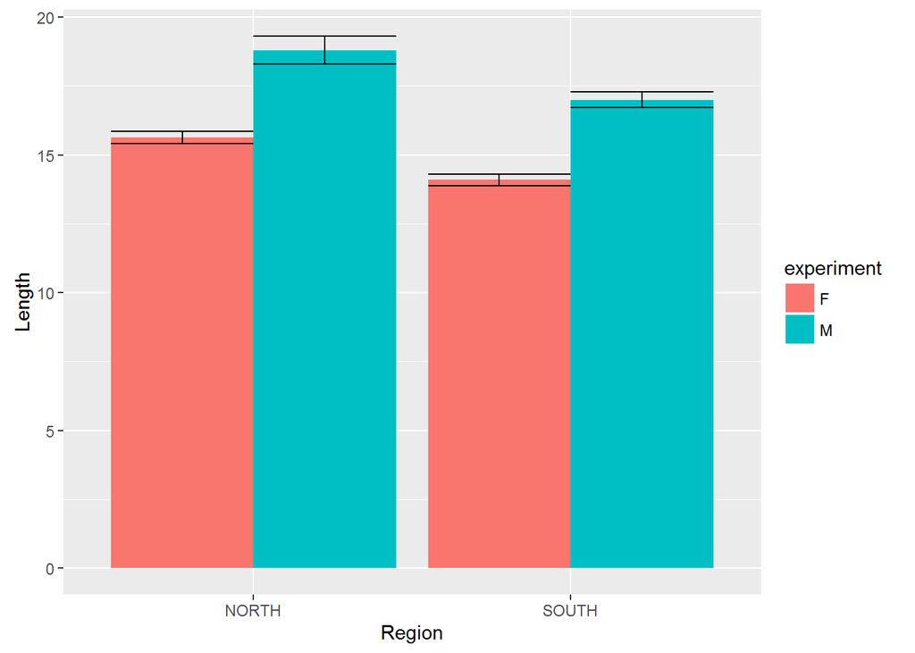

```r
#Load appropriate CSV
labcult = read.csv('C:/Users/Maia.Kapur/Documents/hw1/labcultures.csv')

#find means for sex and region
means = aggregate(formula = Length..mm. ~ Sex + Region, data = labcult, FUN = mean)

#calculate standard error for sex and region
se = aggregate(formula = Length..mm. ~ Sex + Region, data = labcult, FUN = function(x) sqrt(var(x)/length(x)) )

#create a list that contains the values from the above functions
mean = c(means$Length..mm.)
ses = c(se$Length..mm.)

#designate the maximum and minimum values each test into an aes command - this makes
#the ggplot code easier to write

limits <- aes(ymax = mean + ses, ymin = mean - ses)

#create a data frame that includes all the data you need to plot.
#the melt function can quickly lay out your cross -interactions between the
#Region and sex variables
df = melt(data.frame(NORTH = c(15.63, 18.8), SOUTH = c(14.1, 17.0),
    experiment = c("F", "M"),
    variable_name = "metric"))
#plot it, telling ggplot to call from the dataframe (df) you just created
#with Region ("variable") on the x - axis, Length ("value") on the Y, and filled by
#Sex ("experiment")
ggplot(df, aes(x = variable, value, fill = experiment)) +
  geom_bar(position = "dodge", stat = "identity") +
  geom_errorbar(limits, position = "dodge") +
  xlab("Region") +
  ylab("Length")
```

#### 2. Use lm(), and F-tests on the model, to test whether there is a significant difference between Sexes in mean length, whether there is a significant difference between Regions in mean length, and whether the effect of Region differs between Sexes. Report F-statistics and degrees of freedom. How do you interpret these results?

```r
#Generate a linear model for variables of interest, testing for an interaction between the Sex and Region Factors
lsr.noint = lm(labcult$Length..mm. ~ labcult$Region)
lsr.interaction = lm(Length..mm. ~ Sex*Region, data = labcult)
culteff = effect("Sex*Region", lsr.interaction)

#Run ANOVA test using car package to examine significant differences
Anova(lsr.interaction)
```

```
## Anova Table (Type II tests)
##
## Response: Length..mm.
##             Sum Sq  Df F value    Pr(>F)
## Sex         554.12   1 85.5806 < 2.2e-16 ***
## Region      168.00   1 25.9472 6.988e-07 ***
## Sex:Region    0.96   1  0.1484    0.7004
## Residuals  1592.81 246
## ---
## Signif. codes:  0 '***' 0.001 '**' 0.01 '*' 0.05 '.' 0.1 ' ' 1
```

```r
#See F-statistics and Degrees of Freedom in above output.

#It appears there is a significant difference in between sexes and regions in mean length, but a non-significant difference of Region's effect between sexes. Upon visual inspection, this appears to make sense; both Males and Females exhibit higher mean lengths in the North than the South.
```

#### 3 Plot the model-fitted group means and standard errors.

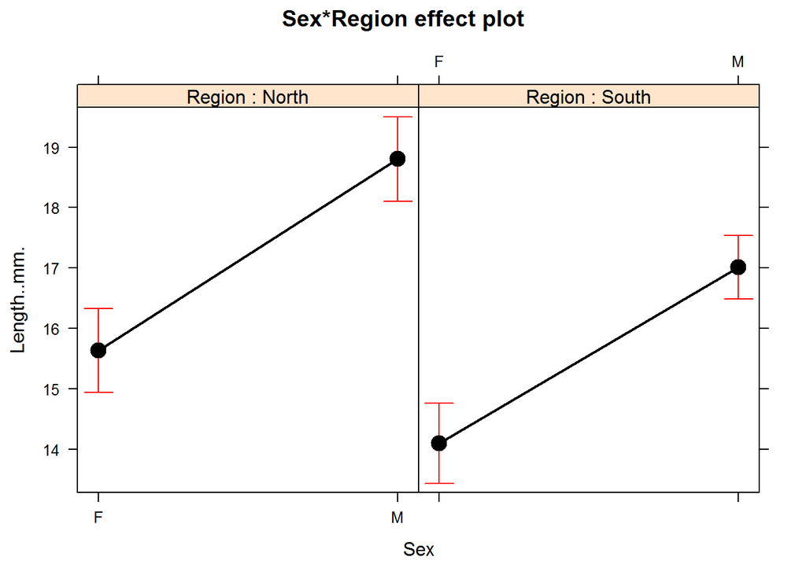

```r
plot(culteff)
```

#### 4: Using the âEgg Dataâ worksheet, plot Number of Eggs vs. Length, and color code the plotted points by Region.

```r
eggs = read.csv('C:/Users/Maia.Kapur/Documents/hw1/eggdata.csv')

#Make new column and designate south/north regions for all populations
eggs$Region = NA
eggs$Region[1:50] = "NORTH"
eggs$Region[51:200] = "NORTH"
eggs$Region[51:150] = "SOUTH"

#Subset individual populations
nahant = subset(eggs, eggs$Population == "Nahant")
Magnolia = subset(eggs, eggs$Population == "Magnolia")
north = rbind(nahant, Magnolia)
VIMS = subset(eggs, eggs$Population == "VIMS")
CCVA = subset(eggs, eggs$Population == "CCVA")
south = rbind(VIMS, CCVA)
```

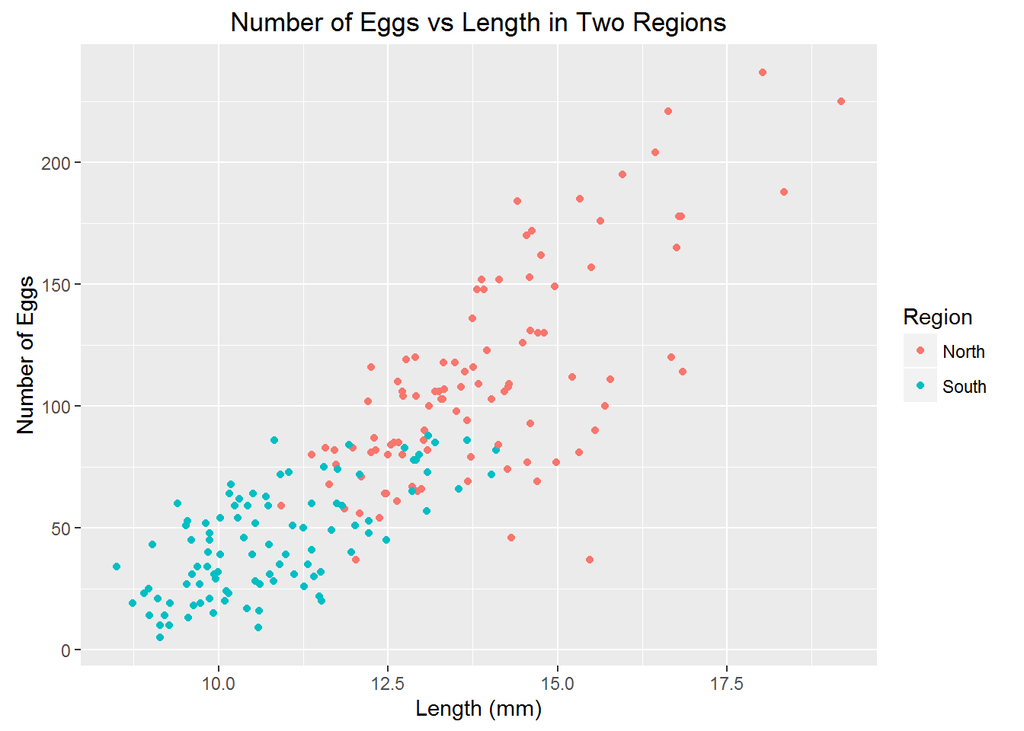

```r
#Plot Regionally-Colored data
ggplot(data=eggs, aes(x=Length..mm., color = Region)) +
  geom_point(data = nahant, aes(y = Number.of.Eggs, color = "North")) +
  geom_point(data = CCVA, aes(y = Number.of.Eggs, color = "South")) +
  geom_point(data = VIMS, aes(y = Number.of.Eggs, color = "South")) +
  geom_point(data = Magnolia, aes(y = Number.of.Eggs, color = "North")) +
  ylab("Number of Eggs") +
  xlab("Length (mm)") +
  ggtitle("Number of Eggs vs Length in Two Regions")
```

#### 5. Fit a linear model to test whether the relationship between Number of Eggs and Length differs between Regions. Perform and report the appropriate F-test to test this question. How might you interpret these results?

```r
#Create a linear model that incorporates both the number of eggs and length for each region
lmr = lm(Number.of.Eggs ~ Length..mm.*Region, data = eggs) #All Regions
lmn = lm(north$Number.of.Eggs ~ north$Length..mm.) #Just the North
lms = lm(south$Number.of.Eggs ~ south$Length..mm.) #Just the South
Anova(lmr)
```

```
## Anova Table (Type II tests)
##
## Response: Number.of.Eggs
##                    Sum Sq  Df  F value    Pr(>F)
## Length..mm.        107208   1 179.5393 < 2.2e-16 ***
## Region               6371   1  10.6689  0.001286 **
## Length..mm.:Region   5696   1   9.5382  0.002304 **
## Residuals          117037 196
## ---
## Signif. codes:  0 '***' 0.001 '**' 0.01 '*' 0.05 '.' 0.1 ' ' 1
```

```r
summary(lmr)
```

```
##
## Call:
## lm(formula = Number.of.Eggs ~ Length..mm. * Region, data = eggs)
##
## Residuals:
##      Min       1Q   Median       3Q      Max
## -102.922  -13.479    0.379   15.391   64.127
##
## Coefficients:
##                         Estimate Std. Error t value Pr(>|t|)
## (Intercept)             -151.316     21.354  -7.086 2.43e-11 ***
## Length..mm.               18.825      1.526  12.333  < 2e-16 ***
## RegionSOUTH               73.091     29.456   2.481   0.0139 *
## Length..mm.:RegionSOUTH   -7.454      2.414  -3.088   0.0023 **
## ---
## Signif. codes:  0 '***' 0.001 '**' 0.01 '*' 0.05 '.' 0.1 ' ' 1
##
## Residual standard error: 24.44 on 196 degrees of freedom
## Multiple R-squared:  0.7388, Adjusted R-squared:  0.7348
## F-statistic: 184.8 on 3 and 196 DF,  p-value: < 2.2e-16
```

```r
#There is a significant difference for No. Eggs across lengths and among the two regions.
```

#### 6. For #5 you have essentially fit two linear regressions, one for each Region. Take your plot from #4 and add these two lines. abline() will help.

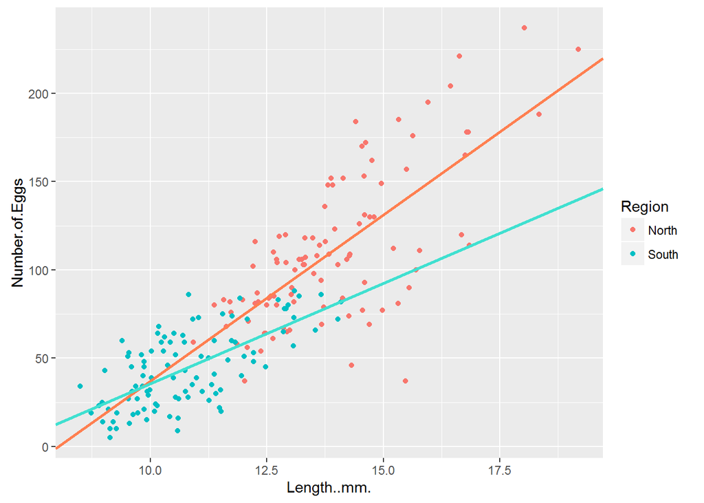

```r
ggplot(data=eggs, aes(x=Length..mm., color = Region, group = 1)) +
  geom_point(data = nahant, aes(y = Number.of.Eggs, color = "North")) +
  geom_point(data = CCVA, aes(y = Number.of.Eggs, color = "South")) +
  geom_point(data = VIMS, aes(y = Number.of.Eggs, color = "South")) +
  geom_point(data = Magnolia, aes(y = Number.of.Eggs, color = "North")) +
  geom_abline(intercept = coef(lmn)[1], slope = coef(lmn)[2], col = "coral", size = 1) +
  geom_abline(intercept = coef(lms)[1], slope = coef(lms)[2], col = "turquoise", size = 1)
```

```r
  ggtitle("Number of Eggs vs Length in Two Regions")
```

```
## $title
## [1] "Number of Eggs vs Length in Two Regions"
##
## attr(,"class")
## [1] "labels"
```

#### 7. Model diagnostics: for the model you fit in #5, make some plots that explore whether the residuals of the model are normally distributed, whether the variance of the residuals increases as Length increases, and whether the variance of the residuals varies between regions.

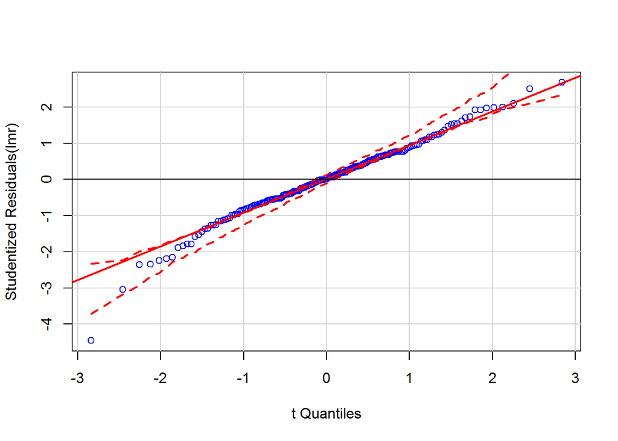

```r
#Plot to inspect distribution of residuals
qqPlot(lmr, col = "blue")
abline(0,0)
```

```r
#The residuals themselves appear normally distributed, with deviation from normality at the tails of the distribution.
```

# Variance of Residuals vs Length

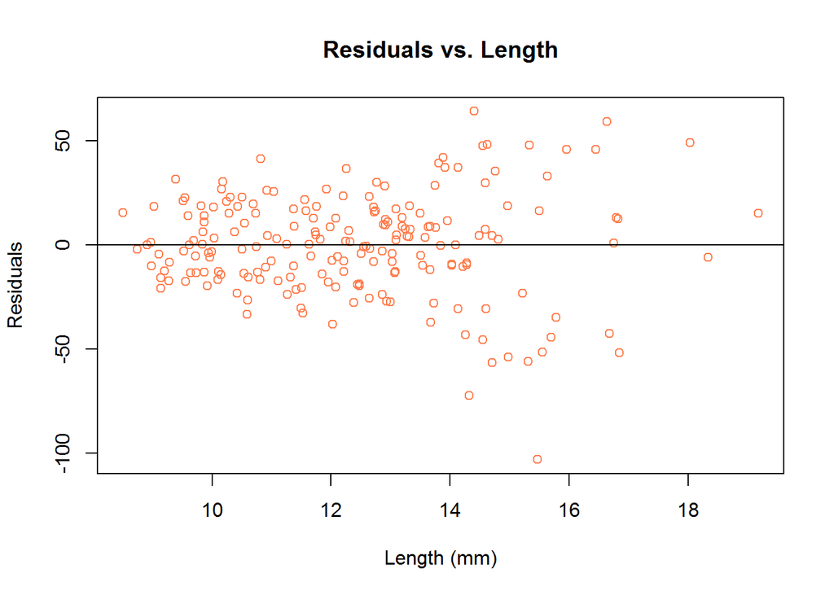

```r
#Calculate model residuals & add to data frame
lmr.residual = resid(lmr)
eggs = cbind(eggs, lmr.residual)

#Plot the Length variable against the residuals
plot(eggs$Length..mm., eggs$lmr.residual, col = "coral", xlab = "Length (mm)", ylab = "Residuals", main = "Residuals vs. Length")
abline(0,0)
```

```r
#The above plot suggests that variance in residuals increases with length.
```

# Variance of Residuals between Regions

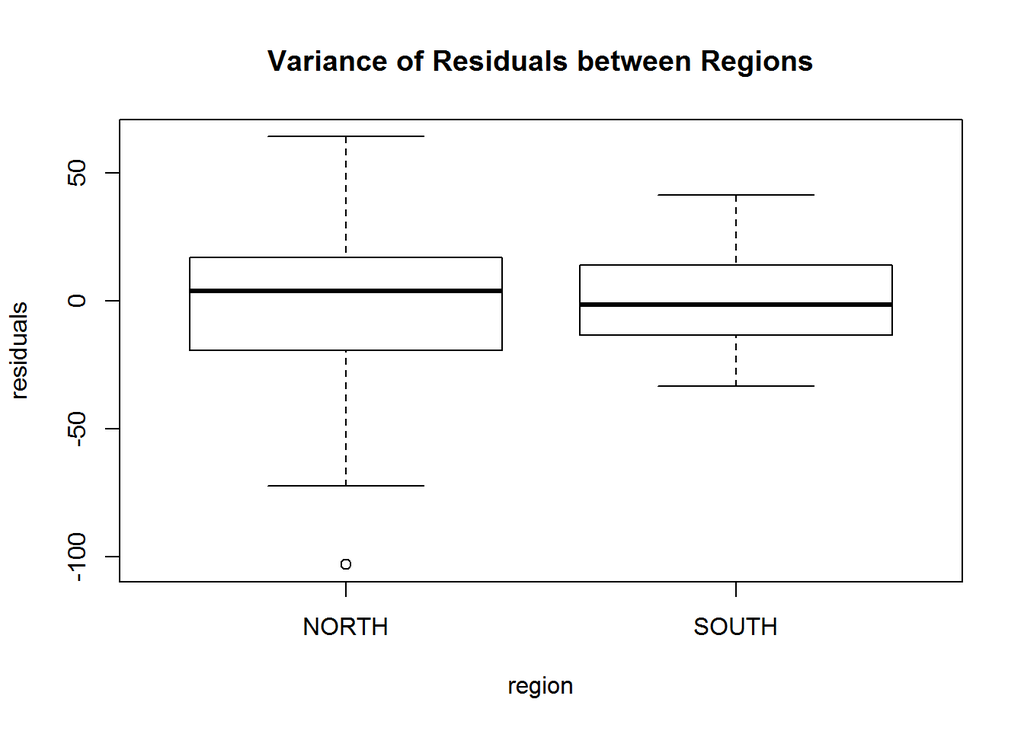

```r
boxplot(eggs$lmr.residual ~ eggs$Region,
        main = "Variance of Residuals between Regions",
        ylab = "residuals",
        xlab = "region")
```